# Magnitudes for catalog v5.1

Route A local magnitudes recomputed with the v5.1 hypocentres. Built 2026-11-25 by `scale/run_magnitude_v51.sh` (chain), `workflow/05_magnitude/v51_build_arrivals.py`, `v51_magnitude_table.py`, `workflow/06_analysis/v51_mc_b.py` (Mc, b) and `workflow/05_magnitude/v51_magnitude_report.py` (this page), branch `analysis/v51-mag`. Large files in `/wd1/mdenolle_data/catalog_v5/v5.1_analysis/mag/`; tables and figures in `data/catalog_v5/v5.1_analysis/mag/`. Private working material, not peer reviewed.

## Context (added 2026-11-25, after review)

- **These magnitudes will be redone.** They use the v5.1 hypocentres. Since then the PI adopted velocity model v0.4.0 (v0.3.1 re-inverted with the re-timed picks, D-B082); v0.4.1, with a surface floor in the inversion (D-B083), is being built. Catalog v6.0 (D-B079, NonLinLoc with SSST station terms) will supersede v5.1, and the magnitudes will be recomputed on it with this chain. Nothing on this page was rerun for those changes.
- **Waveform review of four v5.1 location problems** (`/wd1/mdenolle_data/catalog_v5/v5.1_review/index.html`). (1) Mount St. Helens deep events: the analog UW channels HSR, EDM and STD carry a weekly artificial signal on Wednesdays 19:14-19:21 UTC from 2011-05 to 2013-08. The deep events are 96% UW P picks, 80% within 0.5 s, 73% without S; they are likely false events, pending human review. Of the 331 events of that set, 212 have an ML in both versions; their ML rose by a median +0.59, and 115 of them are among the 639 events whose ML changed by more than 0.5. (2) Brookings 2012: predicted S-P is not monotonic with depth in the v5.1 grids, so about 7-9 km and about 56 km both fit the distant stations, and NonLinLoc took the deep one; the 39 reviewed events with ML in both versions rose by a median +0.17. (3) Tensor events: v5.1 is a median 13.7 km deeper than ComCat, the same result as the tensor comparison below. (4) far_only events moved from near the surface (v4) to 44-64 km; the 856 deep-pass and far_only events of that set with ML in both versions rose by a median +0.10. In all four cases the ML follows the hypocentre and carries its error.

## Summary

- **The phase19 inversion is not converged (found during the review fix; also in v4.1).** LSQR stops at its 3000-iteration limit. Run to convergence (4,863 iterations), the final ML of whole offshore regions moves: Blanco -0.68, JdF ridge/plate -0.51, Gorda -0.28, Mendocino -0.28, onshore labels +0.01 (medians). The converged solution agrees much better with ComCat ML offshore (Blanco +0.59 to +0.10, Gorda +0.33 to +0.02) and with tensor Mw (offshore ML - Mw +0.26 to -0.01). With v4.1 and v5.1 both converged, the offshore ML change between them is -0.001 to +0.042 instead of +0.08 to +0.20. The magnitudes in the table were not changed; see the section on convergence below.
- **Coverage.** 130,349 of the 172,342 v5.1 rows have a magnitude M: 130,232 ML, 84 Mw from ComCat moment tensors and 33 Mw_cal (ML plus a constant, near-recorded events with ML + offset ≥ 4.5). In v4.1: 130,651 ML, 83 Mw, 35 Mw_cal. 126,840 ML come from picks within 150 km ('near'), 3,506 are mapped from the phase3 inversion ('mapped').
- **Rows without a hypocentre.** The 623 rows with loc_source none get no M (490 of them had one in v4.1). A fallback ML_v4hyp, computed at the v4 hypocentre with the v5.1 station terms held fixed, is given in a separate column for 408 of them, and the v4.1 tensor Mw for 3. Neither is written to M.
- **Flags for users.** The table now carries the catalog's depth_quality (for rows with ML: ok 105,567, unconstrained 18,168, biased_deep 6,611) and a column ml_caution for 2,807 rows whose ML may not hold: deep_pass 252 (hypocentre from the deep pass), tierD_moved30 2,666 (tier D and moved more than 30 km in 3D from v4) and weak_terms 78 (every 'near' pick on a station-phase term fitted from fewer than 20 picks).
- **Amplitudes were reused, not re-measured.** The amplitude windows are anchored at the pick (0.3 s before it), but the amplitudes were measured at the uncorrected pick time on day traces assembled the same way as the picker's, so they cover the samples the picker picked. On the 77 re-timed stations the station-magnitude residuals change by -0.028 ± 0.006 (P) and -0.029 ± 0.006 (S) log10 units per second of correction, i.e. at most 0.02 at the largest correction (0.77 s); on stations never re-timed, the same regression against the time of day gives -0.014 (P) and +0.016 (S). Cutting each window short by its correction would change the amplitude by +0.007 (P) and +0.002 (S) log10 units on average (median 0). The window length is re-selected from the stored grid with the v5.1 distance: it changes for 803,484 of 2,495,920 picks (32%; 89% of them by one grid step, median |ΔW| 0.25 s), but the amplitude changes by more than 0.01 log10 units for only 42,374 picks (1.7% of the picks with an amplitude in both runs; mean change +0.0009 over the changed windows).
- **Change from v4.1.** On the 130,003 events with ML in both versions, ML(v5.1) - ML(v4.1) has median +0.047 (IQR +0.001 to +0.096). The offshore/onshore split depends on the definition: with offshore = epicentre below sea level, offshore +0.062 and onshore +0.020, but this counts 3,157 Puget/Georgia inland-water events as offshore (moving them onshore: +0.066 and +0.018). By region label, the ridge, transform and plate labels change by +0.055 and the rest by +0.036; counting Mendocino and Offshore forearc, which straddle the coast, as offshore gives +0.070 and +0.009. By region: Axial -0.11, JdF ridge/plate +0.15, Endeavour +0.14, Explorer +0.10, Gorda +0.10, Mendocino +0.09, Blanco +0.06, offshore forearc +0.07, Puget/Georgia +0.00, Cascades +0.01.
- **Large changes come from tier D relocations.** 1,925 events change by more than 0.3 and 639 by more than 0.5. Of the 639, 529 (83%) are tier D, against 19% tier D among all shared events. 208 lie in the Mount St. Helens box (lat 46.0-46.4, lon -122.4 to -122.0); 173 of them are tier D, their median depth went from 4 km (v4) to 56 km, and 115 are in the deep Mount St. Helens set that the waveform review suspects are false events. The 239 onshore events outside that box are 235 tier D; they moved a median 56 km horizontally and 30 km deeper (median sig_z 15.6 km), and their ML rose by a median +0.66. The remaining 192 are offshore or coastal (121 tier D).
- **Which terms moved.** For events 'near' in both runs, the change equals the per-pick mean of three terms over the common picks: the Hutton-Boore distance term (new hypocentral distances), the station terms and the anchor offset (correlation 0.979, residual std 0.023). With the pick set unchanged this is an accounting identity: it says which terms moved, not why. The window term is about zero (above). The station terms of the ocean-bottom stations dropped (median -0.063 against +0.012 on land), which raises offshore ML. At Axial the epicentres moved toward the caldera stations, so the distance term dropped by 0.33, of which the station terms took back 0.22. Outside Axial, the drop of the seafloor terms comes mostly from the unconverged inversion: with both runs converged, the offshore change is -0.001 to +0.042. These decomposition numbers also move between rebuilds of the v4.1 inversion, which stops before convergence at a point that depends on the floating-point order (BLAS thread count; 12 here): the first version of this page had correlation 0.990 and a seafloor median of -0.047. Events whose depth is poorly constrained rose most: deep-pass events by +0.39 (median depth 86 km in v5.1 against 31 km in v4) and far_only events by +0.10 (52 km against 4 km); their ML inherits the depth error.
- **ComCat.** Against the ComCat ML anchors the v5.1 ML has median residual +0.003 (v4.1: +0.002). That median is near zero by construction, because the median anchor residual sets the offset; the informative numbers are the std, 0.232 (v4.1: 0.212), and the regional gaps. 139 ComCat moment tensors match a v5.1 origin (v4.1: 147); below Mw 4.5 ML - Mw is +0.08 (v4.1: -0.02), above it ML saturates as before and the tensor Mw is used. 8 located events lost their v4.1 tensor match because their v5.1 origin is now 31-101 km and 4.6-12 s from ComCat's; their v4.1 tensor is carried (the event is the same set of picks), which keeps 6 of them at the tensor Mw instead of a saturated ML.
- **Offshore, agreement with both outside references got worse.** For Mw 3-4.5 tensor events, ML - Mw went from -0.02 (v4.1) to +0.08 (v5.1); on the offshore and coastal labels from -0.05 to +0.08 (54 events), onshore from +0.05 to +0.07 (10 events). Our ML sits above ComCat ML at Mendocino, Blanco and Gorda by +0.51, +0.33 and +0.29 (anchor medians; v4.1 +0.44, +0.18, +0.20), so the gap widened by 0.07 to 0.15. Two differences push offshore ML up: longer hypocentral distances (deeper offshore hypocentres, tensor events +13.7 km against ComCat; the distance term changes by -0.01 to +0.05 in the offshore labels outside Axial) and lower seafloor station terms (-0.063). The station-term part, the larger one, comes mostly from the unconverged phase19 inversion (convergence section below): with both runs converged the offshore change is -0.001 to +0.042. So the v5.1 offshore ML is not closer to the outside references than v4.1, and most of the offshore gap itself comes from the solver, not from the relocation.
- **A location result seen through the tensors.** The v5.1 hypocentres of the 139 matched tensor events lie deeper than the ComCat ones (median +13.7 km, IQR +5.0 to +26.1; v4: -2.1) and their origin times earlier (median -0.58 s; v4: -0.07 s). Only 28 of them are far_only and none is from the deep pass. ComCat depths offshore are often fixed (10 km), so this is a flag for the location work, not a magnitude result; the waveform review (problem 3) reports the same offset.
- **Mc and b.** With the v5.1 magnitudes on the v5.1 epicentres (earthquakes only), Mc_best is 2.1 for the whole catalog and b = 1.026 ± 0.017 (bootstrap; v4.1 magnitudes on the same events: 2.1, 1.054). Region by region (v4 cluster boxes), Mc_best changes by AX 0.4 to 0.2, EN 1.8 to 1.9, BL 2.2 to 2.3, GO 2.1 to 2.2, ON 1.3 to 1.2; 0.0 elsewhere. Tested on the same events at a common Mc (Mc_best with the v5.1 magnitudes) with a paired bootstrap, b decreases with the v5.1 magnitudes in 9 of the 11 boxes tested, all beyond the Bonferroni threshold |z| > 2.84: EN 0.872 to 0.794 at Mc 1.9 (-0.079, z -6.8), BL 1.225 to 1.204 at Mc 2.3 (-0.021, z -4.3), GO 1.133 to 1.101 at Mc 2.2 (-0.032, z -3.1), MT 1.007 to 0.973 at Mc 1.7 (-0.035, z -8.5), OR 0.967 to 0.894 at Mc 1.6 (-0.073, z -4.4), PU 1.236 to 1.222 at Mc 1.2 (-0.013, z -2.9), ON 0.801 to 0.742 at Mc 1.2 (-0.060, z -23.7), OFF 1.152 to 1.123 at Mc 2.2 (-0.029, z -8.1), ALL 1.054 to 1.025 at Mc 2.1 (-0.029, z -11.2). It increases in AX 0.694 to 0.715 at Mc 0.2 (+0.021, z +7.9). Not significant: WA (+0.000, z +0.0). At AX the sign depends on Mc: +0.021 at Mc 0.2 and -0.030 at Mc 0.4. The onshore decrease is not driven by Mount St. Helens: without it the ON box goes from 0.802 to 0.754 at Mc 1.2 (-0.049, z -21.5). An earlier version of this page said b changed beyond two bootstrap errors only at AX and ON; that compared b at different Mc with unpaired errors and is withdrawn. All Mc and b values here use the stored (unconverged) ML.

## The phase19 inversion is not converged

phase19 solves station ML = M<sub>i</sub> + C<sub>jp</sub> (one term per station epoch and phase, sum of terms = 0 per phase) with LSQR, damping 10<sup>-3</sup>, and stops at 3000 iterations. On the v5.1 pick set (126,842 events with ≥ 3 near picks) it stops there with istop 7 (iteration limit). Re-solved with the same settings, the final ML agrees with the stored values to within 0.049 (95% within 0.005), so the stored values are reproducible. Run to convergence it stops at 4,863 iterations (istop 2), and the final ML (each solution with its own anchor offset: +0.420 stored, +0.339 converged) changes by more than 0.1 for 55% of events and by more than 0.3 for 21%. The changes are regional, not scatter: whole offshore networks move against the onshore ones. The residual norm hardly changes (268.37 to 267.86), so the picks constrain the level of the offshore station terms relative to the onshore ones only weakly, and the stored level is where LSQR stopped. The same code made the v4.1 magnitudes (the v4.1 rebuild converges at 4,658 iterations). Script: `workflow/05_magnitude/v51_phase19_convergence.py`; tables `phase19_convergence_*.csv`.

### Converged minus stored final ML, by region (events with ≥ 3 near picks)

| region | n | median | p05 | p95 | share_gt_0p1 |
| --- | --- | --- | --- | --- | --- |
| Axial | 13756 | -0.036 | -0.039 | -0.034 | +0.000 |
| Blanco | 30356 | -0.683 | -0.697 | -0.193 | +1.000 |
| Cascades | 16423 | +0.015 | -0.231 | +0.019 | +0.067 |
| Endeavour | 82 | +0.104 | -0.471 | +0.228 | +0.951 |
| Explorer | 841 | -0.077 | -0.304 | +0.112 | +0.410 |
| Gorda | 7440 | -0.281 | -0.487 | -0.255 | +1.000 |
| JdF ridge/plate | 1367 | -0.507 | -0.695 | +0.330 | +0.781 |
| Mendocino | 17758 | -0.280 | -0.286 | -0.277 | +1.000 |
| Offshore forearc | 11392 | -0.277 | -0.282 | +0.014 | +0.631 |
| Other onshore | 13532 | +0.010 | -0.279 | +0.017 | +0.300 |
| Puget/Georgia | 13895 | +0.015 | +0.012 | +0.018 | +0.001 |

### Against the outside references

Anchors and tensors restricted to events with ≥ 3 near picks, so the numbers differ from the anchor table further down, which also holds 'mapped' events and the final M.

**Our ML - ComCat ML (anchor median)**

| region | n | stored | converged |
| --- | --- | --- | --- |
| Axial | 2 | +0.969 | +0.936 |
| Blanco | 41 | +0.594 | +0.095 |
| Cascades | 807 | -0.019 | -0.013 |
| Gorda | 80 | +0.329 | +0.020 |
| Mendocino | 86 | +0.540 | +0.264 |
| Offshore forearc | 338 | -0.019 | -0.045 |
| Other onshore | 771 | +0.034 | +0.028 |
| Puget/Georgia | 1289 | -0.020 | -0.005 |
| all | 3414 | +0.000 | +0.000 |

**Our ML - tensor Mw, Mw 3-4.5 (median)**

| region | n | stored | converged |
| --- | --- | --- | --- |
| all | 52 | +0.222 | -0.004 |
| offshore and coastal labels | 43 | +0.264 | -0.010 |
| onshore labels | 9 | +0.106 | +0.118 |

Converged, the anchor residual std drops from 0.230 to 0.176; the offshore gaps to ComCat ML shrink (Blanco +0.59 to +0.10, Gorda +0.33 to +0.02, Mendocino +0.54 to +0.26), and offshore ML - Mw goes from +0.26 to -0.01 (43 events) while onshore stays near +0.12. Two independent references therefore favour the converged solution offshore.

### v5.1 - v4.1 with both inversions converged

| region | n | stored | converged |
| --- | --- | --- | --- |
| Axial | 13750 | -0.105 | -0.148 |
| Blanco | 30159 | +0.095 | +0.018 |
| Cascades | 16393 | +0.010 | +0.014 |
| Endeavour | 81 | +0.200 | +0.042 |
| Explorer | 820 | +0.142 | +0.023 |
| Gorda | 7376 | +0.119 | +0.006 |
| JdF ridge/plate | 1354 | +0.193 | +0.014 |
| Mendocino | 17696 | +0.114 | +0.001 |
| Offshore forearc | 11343 | +0.083 | -0.001 |
| Other onshore | 13495 | +0.014 | +0.006 |
| Puget/Georgia | 13886 | +0.001 | +0.004 |
| all | 126353 | +0.062 | +0.005 |

Medians over events with ≥ 3 near picks in both runs. Converged, the v5.1 - v4.1 change in the offshore labels outside Axial is -0.001 to +0.042 (stored: +0.083 to +0.200); Axial stays at -0.148 (the hypocentres moved toward the caldera stations). So most of the offshore rise from v4.1 to v5.1, and the drop of the seafloor station terms behind it, come from two unconverged solutions stopping at different points, not from the relocation.

**Consequences.** The offshore ML level of v5.1 and of v4.1 is uncertain by 0.3-0.7 depending on the region, more than any change discussed on this page except at Axial and for relocated tier D events. Mc and b per box are computed from the stored ML; a regional shift moves Mc but not b, and the paired b changes may change once the solver converges. The magnitudes in the table were not changed here: changing the solver changes the v4.1 and v5.1 products and is for the PI to decide; catalog v6.0 will be recomputed anyway. Proposed: run phase19 to convergence (check istop), and map how strongly each offshore deployment is tied to the onshore network.

## Decisions made here (proposed)

[output not shown]

## The chain, v4.1 run against v5.1 run

Same code and options; only the hypocentres and the event list differ. Numbers are read from the two driver logs.

[output not shown]

## Pick timing and the amplitude windows

**How the windows depend on the picks.** For each pick, Route A takes the peak Wood-Anderson amplitude from 0.3 s before the pick to W s after it, with W = 1 + 0.03 r (P, at most 15 s and 0.8 of the S-P time) or 2 + 0.06 r (S, at most 60 s), r the hypocentral distance; the noise level comes from 11 s to 1 s before the pick. So the window position depends on the pick time and its length on the hypocentre.

**Why the existing amplitudes stay valid.** The re-timed picks (D-B072, D-B075) were wrong because the picker read a whole UTC day, ObsPy merged the MiniSEED records into one trace per contiguous segment and timed sample n as segment start + n/100 s, while the digitizer ran slightly off 100 Hz. The amplitude code (`route_a_day_amplitudes.py`) reads the same day from the same archive and merges it the same way (sample time = segment start + n / sampling rate), and it measured each pick at its uncorrected catalog time. The pick and the window therefore share one time base: the window starts 0.3 s before the sample the picker picked. The correction changes the absolute time of the pick (which matters for travel times) but not which samples belong to the arrival; applying it to the amplitude window would move the window off the arrival by up to 0.77 s. The window length only depends on the hypocentre, and the stored running maxima (1-60 s grid) let the v5.1 distance pick a new length without reading waveforms again.

**Check.** 97,367 of the picks used by the phase19 inversion were re-timed by 5 ms or more (51,404 by 0.1 s or more) on 77 station epochs. If the windows were misplaced by the correction, their residuals would fall with the size of the correction. They do not, beyond 0.02-0.03 units at the largest corrections, and the stations that were never re-timed show the same small trend against the time of day (the drift of the listed stations grows through each UTC day, so the correction is also a clock).

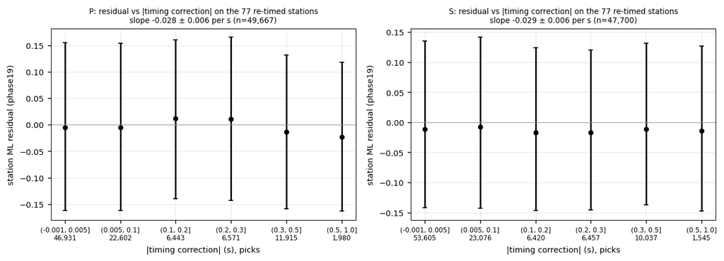

Phase19 station-magnitude residuals on the station epochs that have re-timed picks, binned by the absolute timing correction (median and IQR; numbers of picks under the bins).

| test | slope_per_s | slope_sigma | n |
| --- | --- | --- | --- |
| re-timed picks, residual vs \|correction\|, P | -0.0280 | 0.0061 | 49667 |
| re-timed picks, residual vs \|correction\|, S | -0.0290 | 0.0058 | 47700 |
| control (stations never re-timed), residual vs 0.53 s x day fraction, P | -0.0136 | 0.0024 | 441972 |
| control (stations never re-timed), residual vs 0.53 s x day fraction, S | 0.0161 | 0.0018 | 717348 |

For scale: had a window been misplaced, it would have ended early by the correction. Over the picks re-timed by 0.1 s or more, the ratio of the amplitude in the selected window to the amplitude in the same window cut short by the correction is (log10 units):

| phase | n | median | p25 | p75 | mean | p90 | share_gt_0p1 |
| --- | --- | --- | --- | --- | --- | --- | --- |
| P | 26925 | 0.000 | 0.000 | 0.000 | 0.007 | 0.000 | 0.027 |
| S | 24479 | 0.000 | 0.000 | 0.000 | 0.002 | 0.000 | 0.008 |

Caveats: days whose amplitudes were read from another archive copy (EarthScope fill of incomplete pnwstore days) could have a different segment layout from the picker's; NC and BK were not checked for drift (D-B072). The check above covers the stations that were re-timed.

## Rows without a hypocentre

| item | n |
| --- | --- |
| rows without a hypocentre (loc_source none) | 623 |
| with a v4.1 magnitude | 490 |
| fallback ML_v4hyp (>= 3 picks within 150 km of the v4 hypocentre) | 408 |
| with a v4.1 tensor Mw (kept in Mw_mt_v4) | 3 |

The 623 rows are events NonLinLoc rejected (maximum likelihood on a face of the search grid); 455 are onshore (Cascades and Other onshore labels). Their picks are mostly P (5,360 P and 562 S observations above SNR 3). Where both exist, ML_v4hyp - ML(v4.1) has median -0.005 and IQR -0.041 to +0.033 over 408 events. Table: `nohypo_fallback.csv`.

## Explosions and quarry blasts

3,313 rows carry a non-earthquake flag; 3,280 of them have a magnitude, which is kept (is_earthquake = False). They are left out of the Mc and b fits below.

| flag | n | with_M | M_median | M_max | located |
| --- | --- | --- | --- | --- | --- |
| anss_explosion | 1665 | 1665 | 1.53 | 3.08 | 1665 |
| anss_other_event | 1 | 1 | 0.30 | 0.30 | 1 |
| anss_quarry_blast | 74 | 74 | 2.25 | 2.65 | 74 |
| quarry_blast_likely | 1572 | 1539 | 1.37 | 1.95 | 1572 |
| quarry_blast_likely;anss_explosion | 1 | 1 | 1.64 | 1.64 | 1 |

## Comparison with the v4.1 Route A magnitudes

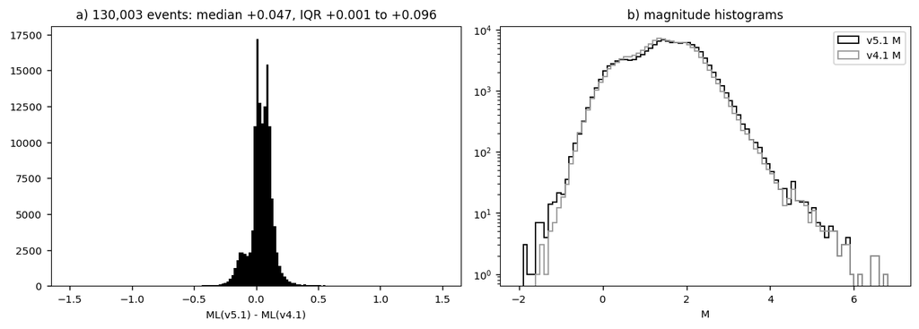

Distribution of the ML change and the magnitude histograms.

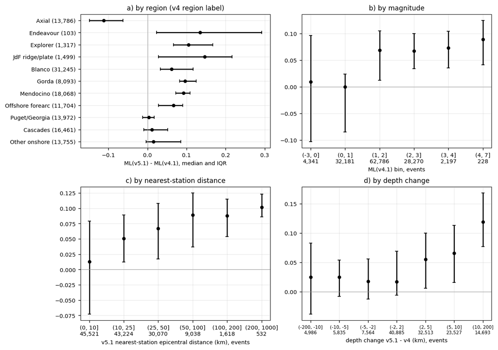

ML(v5.1) - ML(v4.1), median and interquartile range: by region (the region label of the v4 epicentre), by v4.1 ML, by the v5.1 distance to the nearest station and by the depth change.

### By region

| region | n | median | p25 | p75 | mean |
| --- | --- | --- | --- | --- | --- |
| Axial | 13786 | -0.112 | -0.149 | -0.063 | -0.095 |
| Endeavour | 103 | +0.135 | +0.023 | +0.292 | +0.146 |
| Explorer | 1317 | +0.105 | +0.066 | +0.167 | +0.117 |
| JdF ridge/plate | 1499 | +0.146 | +0.028 | +0.216 | +0.123 |
| Blanco | 31245 | +0.062 | +0.033 | +0.117 | +0.075 |
| Gorda | 8093 | +0.096 | +0.082 | +0.125 | +0.108 |
| Mendocino | 18068 | +0.092 | +0.072 | +0.109 | +0.090 |
| Offshore forearc | 11704 | +0.066 | +0.028 | +0.090 | +0.060 |
| Puget/Georgia | 13972 | +0.003 | -0.012 | +0.017 | -0.002 |
| Cascades | 16461 | +0.011 | -0.010 | +0.052 | +0.029 |
| Other onshore | 13755 | +0.015 | -0.004 | +0.085 | +0.040 |

### Offshore and onshore

| offshore_lbl | n | median | p25 | p75 | mean |
| --- | --- | --- | --- | --- | --- |
| offshore | 75993 | +0.062 | +0.012 | +0.104 | +0.047 |
| onshore | 54010 | +0.020 | -0.003 | +0.082 | +0.037 |

Here offshore means an epicentre below sea level (surface_km < 0), which puts the 3,157 Puget/Georgia inland-water events offshore. The split under other definitions (`v51_vs_v4_offshore_definitions.csv`):

| definition | n_offshore | median_offshore | n_onshore | median_onshore |
| --- | --- | --- | --- | --- |
| epicentre below sea level (surface_km < 0) | 75993 | +0.062 | 54010 | +0.020 |
| below sea level, Puget/Georgia counted onshore | 72836 | +0.066 | 57167 | +0.018 |
| region label: ridge, transform and plate labels offshore; Mendocino, Offshore forearc, Puget/Georgia, Cascades, Other onshore onshore | 56043 | +0.055 | 73960 | +0.036 |
| region label: as above but Mendocino and Offshore forearc offshore | 85815 | +0.070 | 44188 | +0.009 |

### By magnitude (v4.1 ML)

| Mbin | n | median | p25 | p75 | mean |
| --- | --- | --- | --- | --- | --- |
| (-3, 0] | 4341 | +0.009 | -0.103 | +0.096 | +0.006 |
| (0, 1] | 32181 | +0.000 | -0.085 | +0.024 | -0.018 |
| (1, 2] | 62786 | +0.069 | +0.012 | +0.105 | +0.064 |
| (2, 3] | 28270 | +0.067 | +0.034 | +0.100 | +0.070 |
| (3, 4] | 2197 | +0.073 | +0.035 | +0.104 | +0.067 |
| (4, 7] | 228 | +0.089 | +0.041 | +0.124 | +0.095 |

### By distance to the nearest station (v5.1)

| dbin | n | median | p25 | p75 | mean |
| --- | --- | --- | --- | --- | --- |
| (0, 10] | 45521 | +0.013 | -0.073 | +0.079 | +0.005 |
| (10, 25] | 43224 | +0.051 | +0.012 | +0.089 | +0.052 |
| (25, 50] | 30070 | +0.067 | +0.017 | +0.108 | +0.069 |
| (50, 100] | 9038 | +0.089 | +0.037 | +0.125 | +0.090 |
| (100, 200] | 1618 | +0.088 | +0.054 | +0.115 | +0.102 |
| (200, 1000] | 532 | +0.102 | +0.086 | +0.123 | +0.107 |

### By depth change (v5.1 - v4, km)

| zbin | n | median | p25 | p75 | mean |
| --- | --- | --- | --- | --- | --- |
| (-200, -10] | 4986 | +0.025 | -0.038 | +0.083 | +0.015 |
| (-10, -5] | 5835 | +0.025 | -0.008 | +0.054 | +0.022 |
| (-5, -2] | 7564 | +0.018 | -0.012 | +0.056 | +0.015 |
| (-2, 2] | 40885 | +0.017 | -0.006 | +0.069 | +0.016 |
| (2, 5] | 32513 | +0.055 | +0.006 | +0.100 | +0.040 |
| (5, 10] | 23527 | +0.066 | +0.016 | +0.113 | +0.055 |
| (10, 200] | 14693 | +0.119 | +0.077 | +0.168 | +0.140 |

### By location flag and tier

| flag | n | median | p25 | p75 | mean |
| --- | --- | --- | --- | --- | --- |
| floor_limited | 5826 | -0.006 | -0.073 | +0.052 | -0.017 |
| far_only | 610 | +0.100 | +0.083 | +0.118 | +0.101 |
| deep_pass | 246 | +0.385 | +0.091 | +0.735 | +0.485 |
| five_phase | 4750 | +0.073 | +0.006 | +0.143 | +0.080 |
| tier A | 20037 | +0.040 | +0.002 | +0.093 | +0.032 |
| tier B | 28113 | +0.036 | -0.006 | +0.089 | +0.027 |
| tier C | 57545 | +0.049 | +0.009 | +0.098 | +0.049 |
| tier D | 24308 | +0.050 | -0.010 | +0.108 | +0.057 |
| non-earthquake flag | 3280 | +0.011 | -0.014 | +0.027 | +0.007 |

Deep-pass events (median depth 86 km in v5.1, 31 km in v4) and far_only events (52 km against 4 km) moved down by tens of km, which lengthens their distances and raises their ML. Their depths are flagged as poorly constrained, so their ML is too (ml_caution deep_pass; far_only events are all 'mapped' and carry the larger mapped uncertainty).

### ML_method, v4.1 to v5.1

| meth | n | median | p25 | p75 | mean |
| --- | --- | --- | --- | --- | --- |
| mapped->mapped | 3251 | +0.093 | +0.067 | +0.114 | +0.094 |
| mapped->near | 172 | +0.123 | -0.083 | +0.308 | +0.004 |
| near->mapped | 228 | -0.025 | -0.136 | +0.251 | +0.128 |
| near->near | 126352 | +0.045 | +0.001 | +0.095 | +0.042 |

### M_type, v4.1 (rows) to v5.1 (columns)

| M_type | M_type v4.1 \ v5.1 | ML | Mw | Mw_cal | none |
| --- | --- | --- | --- | --- | --- |
|  | ML | 129884 | 3 | 3 | 761 |
|  | Mw | 0 | 81 | 0 | 2 |
|  | Mw_cal | 5 | 0 | 30 | 0 |
|  | none | 343 | 0 | 0 | 41230 |

### What moves the magnitudes

For each pick used by both phase19 inversions (same pick_id), the change of the event ML is the mean over its picks of the change of the distance term, of log10 A (window length) and of the station term, plus the change of the anchor offset (+0.406 to +0.420). Over 126,352 events 'near' in both runs this reproduces the observed change with correlation 0.979; the rest comes from picks that enter or leave the 150 km set or the robust rejection. Because the event ML is the mean of (station ML - station term) plus the offset, this is an accounting identity when the pick set is unchanged, not independent evidence of a cause: it tells which terms moved. The window term is near zero: the window length changes for 32% of picks, but only 1.7% of amplitudes change by more than 0.01 log10 units (`window_change.csv`). Why the seafloor station terms dropped is explained only at Axial (the hypocentres moved toward the caldera stations); elsewhere it is not shown.

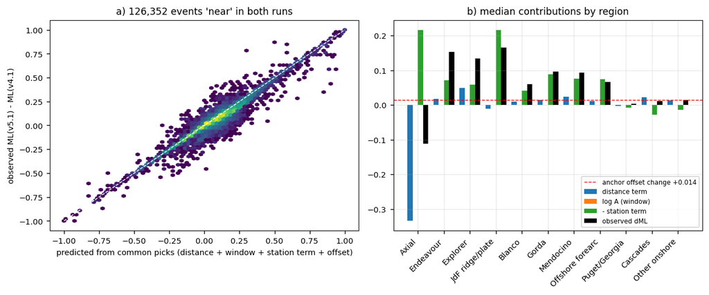

a) observed against reconstructed change; b) median contributions per region.

| region | d_dist | d_logA | d_C | dML | neg_d_C |
| --- | --- | --- | --- | --- | --- |
| Axial | -0.334 | +0.000 | -0.216 | -0.112 | +0.216 |
| Endeavour | +0.018 | +0.000 | -0.071 | +0.153 | +0.071 |
| Explorer | +0.049 | +0.000 | -0.059 | +0.134 | +0.059 |
| JdF ridge/plate | -0.011 | +0.000 | -0.215 | +0.166 | +0.215 |
| Blanco | +0.009 | +0.000 | -0.041 | +0.060 | +0.041 |
| Gorda | +0.015 | +0.000 | -0.088 | +0.096 | +0.088 |
| Mendocino | +0.023 | +0.000 | -0.076 | +0.093 | +0.076 |
| Offshore forearc | +0.011 | +0.000 | -0.074 | +0.066 | +0.074 |
| Puget/Georgia | -0.003 | +0.000 | +0.007 | +0.003 | -0.007 |
| Cascades | +0.022 | +0.000 | +0.028 | +0.011 | -0.028 |
| Other onshore | +0.012 | +0.000 | +0.015 | +0.014 | -0.015 |

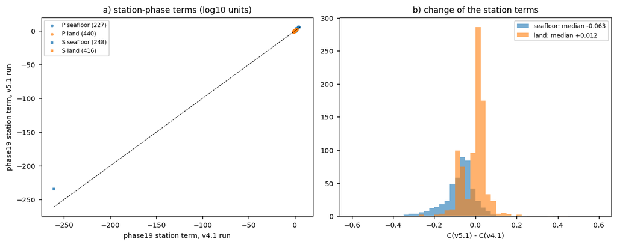

### Large changes

1,925 events change by more than 0.3, 639 by more than 0.5 and 114 by more than 1.0. Of those above 0.5, by region: Cascades 294, Other onshore 153, Blanco 54, Axial 53, Offshore forearc 27, Gorda 20, Puget/Georgia 16, Explorer 8, Mendocino 7, Endeavour 4, JdF ridge/plate 3. 529 of the 639 (83%) are tier D, while tier D is 19% of all shared events, so the large changes come mainly from tier D relocations, not from Mount St. Helens. 208 are in the Mount St. Helens box (173 tier D; median depth 4 km in v4 and 56 km in v5.1; 115 belong to the deep set of the waveform review, problem 1). The 239 onshore events outside the box (235 tier D) moved a median 56 km horizontally and 30 km deeper, with median sig_z 15.6 km, and their ML rose by +0.66. Where the stations are close (Mount St. Helens, Axial), a 1-2 km change of depth can double the hypocentral distance and move the Hutton-Boore term (1.11 log10 r) by 0.3 or more; Hutton-Boore was calibrated at distances of tens of km. Table: `v51_vs_v4_large_changes.csv`.

| group | n | tier_D | deep_pass | in_P1_deep_msh_review | dML_median | shift_h_km_median | shift_z_km_median | sig_z_median | depth_v4_median | depth_v51_median |
| --- | --- | --- | --- | --- | --- | --- | --- | --- | --- | --- |
| all | 639 | 529 | 102 | 115 | 0.63 | 15.25 | 23.40 | 15.99 | 4.96 | 30.93 |
| Mount St. Helens box | 208 | 173 | 76 | 115 | 0.67 | 8.09 | 49.75 | 19.82 | 4.24 | 55.99 |
| onshore labels, outside the Mount St. Helens box | 239 | 235 | 24 | 0 | 0.66 | 56.32 | 30.01 | 15.59 | 9.77 | 42.96 |
| offshore and coastal labels | 192 | 121 | 2 | 0 | 0.54 | 6.12 | 5.58 | 9.03 | 2.12 | 7.13 |

ML change on the event sets of the v5.1 waveform review (sets read from `v5.1_review/work/sets/`; P2 is the 39 reviewed Brookings events):

| review set | n_set | n_shared | dML_median | n_big |
| --- | --- | --- | --- | --- |
| P1 Mount St. Helens deep | 331 | 212 | +0.586 | 115 |
| P2 Brookings 2012 | 39 | 39 | +0.165 | 0 |
| P4 deep-pass and far_only | 980 | 856 | +0.105 | 102 |

### Continuity with v3

Events with an ML in v3, v4.1 and v5.1 (v3-v4 match table; offshore = v5.1 epicentre below sea level). The v4 science report gave v4 - v3 = +0.19 offshore on 41,111 events with its own split; on this set it is +0.17. v5.1 adds about +0.09 offshore.

| group | n | v4_minus_v3 | v51_minus_v3 | v51_minus_v4 |
| --- | --- | --- | --- | --- |
| all | 40038 | +0.121 | +0.206 | +0.071 |
| offshore | 19438 | +0.173 | +0.264 | +0.087 |
| onshore | 20600 | -0.013 | -0.001 | +0.025 |

## Comparison with ComCat

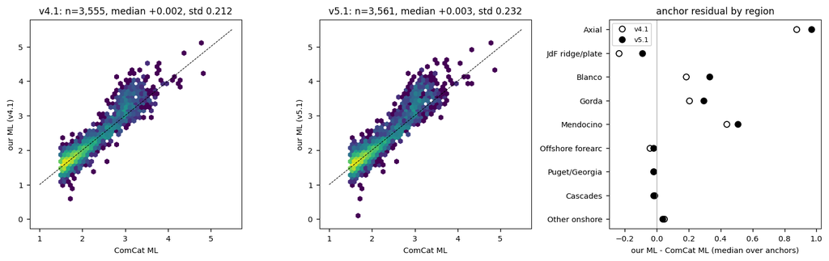

Our ML against the ComCat ML of the phase2 anchors (same ComCat events in both runs).

### Anchor residual (our ML - ComCat ML)

| catalog | group | value | n | median | p25 | p75 | mean | std |
| --- | --- | --- | --- | --- | --- | --- | --- | --- |
| v5.1 | region | Axial | 2 | +0.969 | +0.880 | +1.058 | +0.969 | +0.252 |
| v5.1 | region | Blanco | 103 | +0.330 | +0.102 | +0.539 | +0.342 | +0.377 |
| v5.1 | region | Cascades | 814 | -0.019 | -0.105 | +0.067 | -0.018 | +0.180 |
| v5.1 | region | Gorda | 106 | +0.293 | +0.171 | +0.442 | +0.309 | +0.207 |
| v5.1 | region | JdF ridge/plate | 4 | -0.091 | -0.147 | -0.072 | -0.128 | +0.108 |
| v5.1 | region | Mendocino | 101 | +0.509 | +0.242 | +0.695 | +0.459 | +0.301 |
| v5.1 | region | Offshore forearc | 347 | -0.021 | -0.163 | +0.268 | +0.057 | +0.302 |
| v5.1 | region | Other onshore | 794 | +0.036 | -0.069 | +0.161 | +0.058 | +0.216 |
| v5.1 | region | Puget/Georgia | 1290 | -0.020 | -0.093 | +0.054 | -0.019 | +0.136 |
| v5.1 | off | offshore | 837 | +0.072 | -0.059 | +0.340 | +0.152 | +0.300 |
| v5.1 | off | onshore | 2724 | -0.009 | -0.097 | +0.092 | +0.006 | +0.194 |
| v5.1 | all | all | 3561 | +0.003 | -0.089 | +0.123 | +0.040 | +0.232 |
| v5.1 | ComCat ML | 1.5-2.5 | 2878 | -0.010 | -0.094 | +0.083 | -0.001 | +0.172 |
| v5.1 | ComCat ML | 2.5-3.5 | 633 | +0.182 | -0.050 | +0.471 | +0.224 | +0.338 |
| v5.1 | ComCat ML | 3.5-6 | 50 | +0.008 | -0.166 | +0.233 | +0.093 | +0.378 |
| v4.1 | region | Axial | 2 | +0.875 | +0.817 | +0.934 | +0.875 | +0.165 |
| v4.1 | region | Blanco | 96 | +0.182 | -0.060 | +0.486 | +0.238 | +0.410 |
| v4.1 | region | Cascades | 814 | -0.015 | -0.097 | +0.068 | -0.021 | +0.169 |
| v4.1 | region | Gorda | 106 | +0.204 | +0.077 | +0.349 | +0.213 | +0.205 |
| v4.1 | region | JdF ridge/plate | 2 | -0.238 | -0.292 | -0.184 | -0.238 | +0.153 |
| v4.1 | region | Mendocino | 102 | +0.436 | +0.152 | +0.599 | +0.364 | +0.297 |
| v4.1 | region | Offshore forearc | 348 | -0.044 | -0.184 | +0.189 | +0.014 | +0.276 |
| v4.1 | region | Other onshore | 795 | +0.045 | -0.059 | +0.159 | +0.053 | +0.196 |
| v4.1 | region | Puget/Georgia | 1290 | -0.021 | -0.095 | +0.052 | -0.020 | +0.136 |
| v4.1 | off | offshore | 825 | +0.042 | -0.083 | +0.244 | +0.102 | +0.276 |
| v4.1 | off | onshore | 2730 | -0.008 | -0.095 | +0.087 | +0.001 | +0.182 |
| v4.1 | all | all | 3555 | +0.002 | -0.093 | +0.112 | +0.024 | +0.212 |
| v4.1 | ComCat ML | 1.5-2.5 | 2880 | -0.008 | -0.094 | +0.079 | -0.005 | +0.162 |
| v4.1 | ComCat ML | 2.5-3.5 | 626 | +0.121 | -0.083 | +0.367 | +0.162 | +0.318 |
| v4.1 | ComCat ML | 3.5-6 | 49 | -0.033 | -0.200 | +0.181 | +0.021 | +0.371 |

### All ANSS magnitudes of matched events, by magnitude type (v5.1 M - ANSS mag)

| anss_magtype | n | median | p25 | p75 | mean | v4_median |
| --- | --- | --- | --- | --- | --- | --- |
| md | 11939 | +0.313 | +0.114 | +0.480 | +0.285 | +0.272 |
| ml | 4321 | +0.054 | -0.073 | +0.177 | +0.065 | +0.050 |
| mb | 154 | -0.445 | -0.685 | -0.054 | -0.358 | -0.582 |
| mw | 152 | +0.154 | -0.010 | +0.369 | +0.151 | +0.063 |
| mwr | 48 | -0.120 | -0.659 | +0.010 | -0.328 | -0.306 |
| mh | 29 | -0.310 | -0.486 | -0.014 | -0.123 | -0.395 |
| mww | 25 | +0.010 | +0.000 | +0.030 | +0.011 | +0.000 |

### ComCat moment tensors

| catalog | Mw_class | n | ML_minus_Mw | dist_km_median | ddepth_km_median |
| --- | --- | --- | --- | --- | --- |
| v5.1 | 3-4.5 | 64 | +0.08 | +5.30 | +8.10 |
| v5.1 | 4.5-5.5 | 56 | -0.80 | +18.50 | +23.65 |
| v5.1 | 5.5-7.5 | 19 | -0.94 | +20.70 | +13.70 |
| v5.1 | all matched | 139 |  | +12.90 | +13.70 |
| v5.1 | 3-4.5, offshore labels | 54 | +0.08 | +5.30 | +9.20 |
| v5.1 | 3-4.5, onshore labels | 10 | +0.07 | +5.00 | +3.15 |
| v4.1 | 3-4.5 | 67 | -0.02 | +5.50 | -0.50 |
| v4.1 | 4.5-5.5 | 60 | -0.79 | +20.60 | -4.85 |
| v4.1 | 5.5-7.5 | 20 | -1.01 | +23.50 | -4.75 |
| v4.1 | all matched | 147 |  | +14.20 | -2.10 |
| v4.1 | 3-4.5, offshore labels | 57 | -0.05 | +5.10 | +1.70 |
| v4.1 | 3-4.5, onshore labels | 10 | +0.05 | +8.70 | -2.85 |

Tensors matched by phase18 in v4.1 but not in v5.1: 11 (nc71819471, nc72642536, nc72689331, us10002w8x, us100049ky, us10007cww, us20003nmz, us20004hil, usb000iiju, usc000tb91, usp000jegf); new matches: 3 (us10004gmw, usp000hmk3, usp000jqge). A match needs |dt| < 5 s and < 50 km. Three of the lost ones are rows without a hypocentre (their tensor Mw is in Mw_mt_v4). For the located ones the v4.1 tensor is carried (mt_match = v4.1):

| ID | region | tier | far_only | depth | shift_h_km | shift_z_km | comcat_id | Mw_mt | ML | M | M_type | M_v4 | M_type_v4 |
| --- | --- | --- | --- | --- | --- | --- | --- | --- | --- | --- | --- | --- | --- |
| 25052 | Explorer | C | False | 64.69 | 10.35 | 36.72 | usp000jegf | 4.75 | 4.07 | 4.75 | Mw | 4.75 | Mw |
| 31192 | Mendocino | D | False | 63.96 | 68.86 | 30.01 | nc71819471 | 5.19 | 5.28 | 5.19 | Mw | 5.19 | Mw |
| 63461 | Blanco | C | False | 24.94 | 3.32 | 23.15 | usb000iiju | 4.57 | 4.18 | 4.57 | Mw | 4.57 | Mw |
| 113182 | Explorer | D | True | 62.57 | 48.40 | 58.27 | usc000tb91 | 5.34 | 4.45 | 5.34 | Mw | 5.34 | Mw |
| 156577 | Explorer | D | True | 10.93 | 60.84 | 3.14 | us10002w8x | 4.77 | 3.48 | 4.77 | Mw | 4.77 | Mw |
| 160800 | Explorer | D | True | 53.36 | 113.14 | 47.64 | us20003nmz | 5.74 | 4.43 | 5.74 | Mw | 5.74 | Mw |
| 165020 | Explorer | D | False | 42.38 | 81.87 | 39.98 | us100049ky | 4.28 | 3.21 | 3.21 | ML | 3.31 | ML |
| 171983 | Blanco | D | False | 65.93 | 23.43 | 67.31 | us10007cww | 4.24 | 3.96 | 3.96 | ML | 3.75 | ML |

Matched tensor events by v5.1 flag: far_only 28 of 139; tiers A 16, B 17, C 86, D 20. Median depth difference (ours - ComCat) by region: Blanco +13.0 km, Cascades +3.9 km, Explorer +24.9 km, Gorda +13.7 km, JdF ridge/plate -7.3 km, Mendocino +13.9 km, Offshore forearc +11.0 km, Other onshore +4.7 km, Puget/Georgia +4.3 km.

## Magnitude of completeness and b-values

Estimators of `v4_mc_maps.py`: MAXC + 0.2, MBS, GFT90/95 and the Woessner & Wiemer (2005) 'best' rule; Aki-Utsu b with the Shi & Bolt error; 200 bootstrap resamples. Maps: nearest 250 events within 50 km of each 0.1 deg node (150 for the periods). Events: located in v5.1, with M, earthquakes only (C). B uses the v4.1 magnitudes on the same events and epicentres, A the v4.1 magnitudes on the v4 epicentres with every event (the v4 Mc maps).

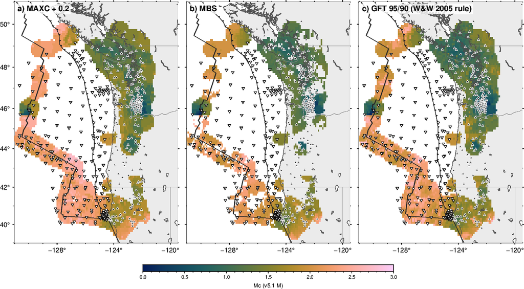

Mc from the three estimators, v5.1 magnitudes. White inverted triangles: seafloor stations; dark triangles: land stations.

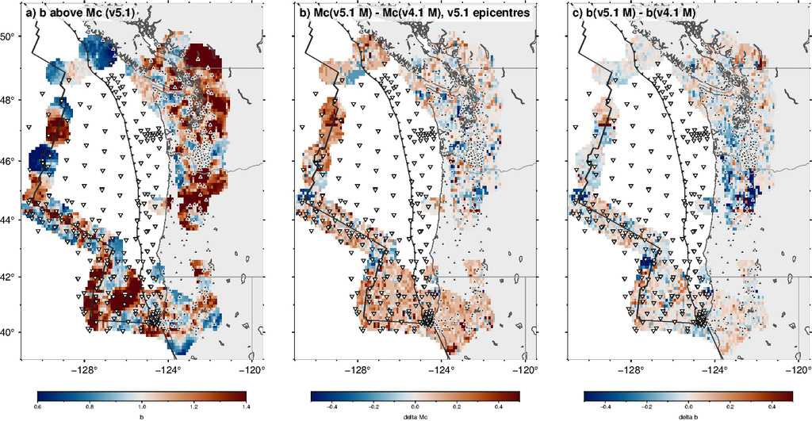

a) b above Mc_best; b) change of Mc_best and c) of b when the v4.1 magnitudes are replaced by the v5.1 ones on the same events.

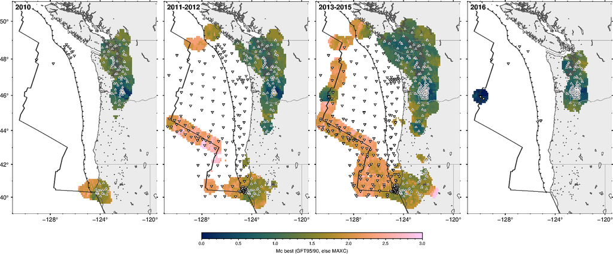

Mc_best per deployment period, with the stations open in each period.

### Regional Mc and b (v4 cluster boxes), all years

**C: v5.1 M**

| region | n | mc_maxc | mc_mbs | mc_gft90 | mc_gft95 | mc_best | sigma_boot | b | b_sigma | b_sigma_boot | b_maxc | b_maxc_sigma_boot |
| --- | --- | --- | --- | --- | --- | --- | --- | --- | --- | --- | --- | --- |
| AX | 13866 | 0.50 | 0.30 | 0.10 | 0.20 | 0.20 | 0.00 | 0.71 | 0.01 | 0.01 | 0.76 | 0.01 |
| EN | 1874 | 2.20 | 2.00 | 1.90 |  | 1.90 | 0.11 | 0.80 | 0.02 | 0.05 | 0.89 | 0.03 |
| BL | 31609 | 2.40 | 2.50 | 2.10 | 2.30 | 2.30 | 0.04 | 1.21 | 0.01 | 0.03 | 1.25 | 0.01 |
| GO | 7106 | 2.30 | 2.30 | 2.00 | 2.20 | 2.20 | 0.03 | 1.10 | 0.02 | 0.03 | 1.14 | 0.02 |
| MT | 28658 | 1.70 | 2.70 | 1.50 | 1.70 | 1.70 | 0.09 | 0.98 | 0.01 | 0.02 | 0.98 | 0.01 |
| WA | 2773 | 1.20 | 1.30 | 1.00 | 1.20 | 1.20 | 0.07 | 1.00 | 0.03 | 0.05 | 1.00 | 0.03 |
| OR | 1248 | 1.80 | 1.50 | 1.40 | 1.60 | 1.60 | 0.19 | 0.89 | 0.03 | 0.07 | 0.85 | 0.03 |
| PU | 13044 | 1.20 | 1.30 | 1.00 | 1.20 | 1.20 | 0.04 | 1.22 | 0.02 | 0.03 | 1.22 | 0.02 |
| ON | 26891 | 0.70 | 2.60 | 1.00 | 1.20 | 1.20 | 0.05 | 0.74 | 0.01 | 0.02 | 0.56 | 0.00 |
| OFF | 44610 | 2.40 | 2.40 | 2.10 | 2.20 | 2.20 | 0.03 | 1.12 | 0.01 | 0.02 | 1.20 | 0.01 |
| ALL | 127069 | 1.70 | 2.30 | 1.90 | 2.10 | 2.10 | 0.03 | 1.03 | 0.01 | 0.02 | 0.78 | 0.00 |

**B: v4.1 M, same events**

| region | n | mc_maxc | mc_mbs | mc_gft90 | mc_gft95 | mc_best | sigma_boot | b | b_sigma | b_sigma_boot | b_maxc | b_maxc_sigma_boot |
| --- | --- | --- | --- | --- | --- | --- | --- | --- | --- | --- | --- | --- |
| AX | 14015 | 0.70 | 0.40 | 0.20 | 0.40 | 0.40 | 0.91 | 0.79 | 0.01 | 0.19 | 0.79 | 0.01 |
| EN | 1859 | 2.20 | 1.90 | 1.80 |  | 1.80 | 0.05 | 0.81 | 0.02 | 0.04 | 0.88 | 0.04 |
| BL | 31496 | 2.30 | 2.50 | 2.00 | 2.20 | 2.20 | 0.04 | 1.18 | 0.01 | 0.02 | 1.23 | 0.01 |
| GO | 7075 | 2.30 | 2.20 | 1.90 | 2.10 | 2.10 | 0.03 | 1.09 | 0.02 | 0.03 | 1.14 | 0.03 |
| MT | 28626 | 1.60 | 1.80 | 1.40 | 1.70 | 1.70 | 0.21 | 1.01 | 0.01 | 0.04 | 0.97 | 0.01 |
| WA | 2763 | 1.30 | 1.30 | 1.00 | 1.20 | 1.20 | 0.09 | 1.00 | 0.03 | 0.05 | 1.04 | 0.03 |
| OR | 1242 | 1.80 | 1.60 | 1.40 | 1.60 | 1.60 | 0.15 | 0.97 | 0.04 | 0.08 | 0.98 | 0.05 |
| PU | 13049 | 1.20 | 1.30 | 1.00 | 1.20 | 1.20 | 0.08 | 1.23 | 0.02 | 0.04 | 1.23 | 0.02 |
| ON | 26874 | 1.50 | 1.60 | 1.10 | 1.30 | 1.30 | 0.02 | 0.85 | 0.01 | 0.02 | 0.88 | 0.01 |
| OFF | 44435 | 2.30 | 2.40 | 2.00 | 2.20 | 2.20 | 0.00 | 1.15 | 0.01 | 0.01 | 1.19 | 0.01 |
| ALL | 126999 | 1.50 | 2.30 | 1.90 | 2.10 | 2.10 | 0.02 | 1.05 | 0.01 | 0.01 | 0.72 | 0.00 |

**A: v4.1 M, v4 epicentres, all events**

| region | n | mc_maxc | mc_mbs | mc_gft90 | mc_gft95 | mc_best | sigma_boot | b | b_sigma | b_sigma_boot | b_maxc | b_maxc_sigma_boot |
| --- | --- | --- | --- | --- | --- | --- | --- | --- | --- | --- | --- | --- |
| AX | 13913 | 0.70 | 0.40 | 0.20 |  | 0.20 | 0.94 | 0.70 | 0.01 | 0.19 | 0.80 | 0.01 |
| EN | 1823 | 2.20 | 1.90 | 1.80 |  | 1.80 | 0.05 | 0.81 | 0.02 | 0.04 | 0.89 | 0.04 |
| BL | 31563 | 2.30 | 2.50 | 2.00 | 2.20 | 2.20 | 0.03 | 1.17 | 0.01 | 0.02 | 1.22 | 0.01 |
| GO | 6964 | 2.30 | 2.20 | 1.90 | 2.10 | 2.10 | 0.06 | 1.09 | 0.02 | 0.04 | 1.14 | 0.03 |
| MT | 28750 | 1.60 | 1.80 | 1.40 | 1.70 | 1.70 | 0.17 | 1.01 | 0.01 | 0.04 | 0.96 | 0.01 |
| WA | 2828 | 1.30 | 1.40 | 1.00 | 1.20 | 1.20 | 0.09 | 0.99 | 0.03 | 0.05 | 1.04 | 0.03 |
| OR | 1393 | 1.70 | 1.60 | 1.40 | 1.60 | 1.60 | 0.08 | 1.03 | 0.04 | 0.06 | 1.07 | 0.04 |
| PU | 13348 | 1.20 | 1.40 | 1.00 | 1.20 | 1.20 | 0.16 | 1.22 | 0.02 | 0.07 | 1.22 | 0.02 |
| ON | 30190 | 1.50 | 1.40 | 1.10 | 1.30 | 1.30 | 0.00 | 0.92 | 0.01 | 0.01 | 0.95 | 0.01 |
| OFF | 44571 | 2.30 | 2.40 | 2.00 | 2.20 | 2.20 | 0.01 | 1.15 | 0.01 | 0.01 | 1.18 | 0.01 |
| ALL | 130772 | 1.60 | 2.30 | 1.90 | 2.10 | 2.10 | 0.02 | 1.05 | 0.01 | 0.01 | 0.77 | 0.00 |

### Change, region by region

| region | n | mc_best | b | b_sigma_boot | mc_best_B | b_B | mc_best_A | b_A | d_mc_C_minus_B | d_b_C_minus_B |
| --- | --- | --- | --- | --- | --- | --- | --- | --- | --- | --- |
| AX | 13866 | 0.20 | 0.71 | 0.01 | 0.40 | 0.79 | 0.20 | 0.70 | -0.20 | -0.08 |
| EN | 1874 | 1.90 | 0.80 | 0.05 | 1.80 | 0.81 | 1.80 | 0.81 | 0.10 | -0.02 |
| BL | 31609 | 2.30 | 1.21 | 0.03 | 2.20 | 1.18 | 2.20 | 1.17 | 0.10 | 0.03 |
| GO | 7106 | 2.20 | 1.10 | 0.03 | 2.10 | 1.09 | 2.10 | 1.09 | 0.10 | 0.01 |
| MT | 28658 | 1.70 | 0.98 | 0.02 | 1.70 | 1.01 | 1.70 | 1.01 | 0.00 | -0.03 |
| WA | 2773 | 1.20 | 1.00 | 0.05 | 1.20 | 1.00 | 1.20 | 0.99 | 0.00 | 0.00 |
| OR | 1248 | 1.60 | 0.89 | 0.07 | 1.60 | 0.97 | 1.60 | 1.03 | 0.00 | -0.08 |
| PU | 13044 | 1.20 | 1.22 | 0.03 | 1.20 | 1.23 | 1.20 | 1.22 | 0.00 | -0.01 |
| ON | 26891 | 1.20 | 0.74 | 0.02 | 1.30 | 0.85 | 1.30 | 0.92 | -0.10 | -0.11 |
| OFF | 44610 | 2.20 | 1.12 | 0.02 | 2.20 | 1.15 | 2.20 | 1.15 | 0.00 | -0.03 |
| ALL | 127069 | 2.10 | 1.03 | 0.02 | 2.10 | 1.05 | 2.10 | 1.05 | 0.00 | -0.03 |

This table compares C and B each at its own Mc_best, and b_sigma_boot is the error of C alone, so it cannot test the change. The paired test below does.

### Paired test of the b change (same events, common Mc)

Events located in v5.1, earthquakes, with both a v5.1 and a v4.1 M. For each box, b of the v4.1 and of the v5.1 magnitudes above one common Mc (Mc_best of C, and Mc_best of B where it differs); sd_paired is the std of b(v5.1) - b(v4.1) over 500 bootstrap resamples of the events, with Mc held fixed. Bonferroni over the 11 boxes tested at Mc_best of C: |z| > 2.84 for a family-wise 5% level. 'ON without MSH' and 'MSH only' split the onshore box at the Mount St. Helens box (lat 46.0-46.4, lon -122.4 to -122.0). Computed by `v51_mc_b.py --stage paired` (`mc_b/paired_b.csv`).

| box | mc_source | mc | n_events | n_above_v41 | n_above_v51 | b_v41 | b_v51 | db | sd_paired | z | significant_bonferroni |
| --- | --- | --- | --- | --- | --- | --- | --- | --- | --- | --- | --- |
| AX | Mc_best C | 0.200 | 13865 | 11601 | 10351 | 0.694 | 0.715 | 0.021 | 0.003 | 7.875 | True |
| AX | Mc_best B | 0.400 | 13865 | 9369 | 7813 | 0.789 | 0.759 | -0.030 | 0.004 | -7.492 | True |
| EN | Mc_best C | 1.900 | 1856 | 1214 | 1418 | 0.872 | 0.794 | -0.079 | 0.012 | -6.781 | True |
| EN | Mc_best B | 1.800 | 1856 | 1375 | 1545 | 0.814 | 0.726 | -0.087 | 0.009 | -9.163 | True |
| BL | Mc_best C | 2.300 | 31454 | 10425 | 12174 | 1.225 | 1.204 | -0.021 | 0.005 | -4.307 | True |
| BL | Mc_best B | 2.200 | 31454 | 13221 | 15227 | 1.177 | 1.148 | -0.029 | 0.004 | -7.403 | True |
| GO | Mc_best C | 2.200 | 7056 | 2618 | 3319 | 1.133 | 1.101 | -0.032 | 0.010 | -3.127 | True |
| GO | Mc_best B | 2.100 | 7056 | 3264 | 4011 | 1.093 | 1.040 | -0.053 | 0.009 | -5.947 | True |
| MT | Mc_best C | 1.700 | 28593 | 11696 | 13809 | 1.007 | 0.973 | -0.035 | 0.004 | -8.497 | True |
| WA | Mc_best C | 1.200 | 2762 | 1261 | 1341 | 0.998 | 0.998 | 0.000 | 0.008 | 0.047 | False |
| OR | Mc_best C | 1.600 | 1241 | 669 | 730 | 0.967 | 0.894 | -0.073 | 0.017 | -4.388 | True |
| PU | Mc_best C | 1.200 | 13041 | 5042 | 5029 | 1.236 | 1.222 | -0.013 | 0.005 | -2.891 | True |
| ON | Mc_best C | 1.200 | 26858 | 9676 | 9960 | 0.801 | 0.742 | -0.060 | 0.003 | -23.674 | True |
| ON | Mc_best B | 1.300 | 26858 | 8480 | 8726 | 0.849 | 0.774 | -0.075 | 0.003 | -24.010 | True |
| OFF | Mc_best C | 2.200 | 44369 | 16794 | 19779 | 1.152 | 1.123 | -0.029 | 0.004 | -8.123 | True |
| ALL | Mc_best C | 2.100 | 126726 | 27735 | 32421 | 1.054 | 1.025 | -0.029 | 0.003 | -11.210 | True |
| ON without MSH | Mc_best C | 1.200 | 17041 | 8779 | 9042 | 0.802 | 0.754 | -0.049 | 0.002 | -21.450 | True |
| ON without MSH | Mc_best B | 1.300 | 17041 | 7692 | 7922 | 0.851 | 0.789 | -0.061 | 0.003 | -22.428 | True |
| MSH only | Mc_best C | -0.100 | 9817 | 8139 | 8359 | 0.687 | 0.670 | -0.017 | 0.003 | -6.887 | True |

Result: b is lower with the v5.1 magnitudes in EN, BL, GO, MT, OR, PU, ON, OFF, ALL and higher in AX (beyond the Bonferroni threshold); not significant in WA. At AX the sign depends on Mc: +0.021 at Mc 0.2 and -0.030 at Mc 0.4. The changes are small (a few percent of b), and their cause is not analysed here: a slope of only 0.03 in ML(v5.1) - ML(v4.1) against magnitude would lower b by about 3%. They come from the magnitudes alone, since both b values use the same events and epicentres.

### Per period, v5.1 (C)

| period | region | n | mc_maxc | mc_mbs | mc_gft90 | mc_gft95 | mc_best | sigma_boot | b | b_sigma | b_sigma_boot | b_maxc | b_maxc_sigma_boot |
| --- | --- | --- | --- | --- | --- | --- | --- | --- | --- | --- | --- | --- | --- |
| 2010 | AX | 0 |  |  |  |  |  |  |  |  |  |  |  |
| 2010 | EN | 53 |  |  |  |  |  |  |  |  |  |  |  |
| 2010 | BL | 73 |  |  |  |  |  |  |  |  |  |  |  |
| 2010 | GO | 171 | 2.50 | 2.30 | 2.20 |  | 2.20 | 0.13 | 0.74 | 0.05 | 0.08 | 0.82 | 0.09 |
| 2010 | MT | 3872 | 2.00 | 1.90 | 1.60 | 1.80 | 1.80 | 0.18 | 0.95 | 0.02 | 0.07 | 0.99 | 0.03 |
| 2010 | WA | 378 | 1.70 | 1.40 | 1.20 | 1.40 | 1.40 | 0.14 | 1.08 | 0.09 | 0.12 | 1.01 | 0.11 |
| 2010 | OR | 102 | 1.90 | 1.30 | 1.30 |  | 1.30 | 0.25 | 0.66 | 0.07 | 0.12 | 0.70 | 0.14 |
| 2010 | PU | 2337 | 1.30 | 1.50 | 1.10 | 1.50 | 1.50 | 0.16 | 1.63 | 0.08 | 0.19 | 1.48 | 0.05 |
| 2010 | ON | 3250 | 1.50 | 1.30 | 1.10 | 1.30 | 1.30 | 0.06 | 0.88 | 0.02 | 0.04 | 0.90 | 0.03 |
| 2010 | OFF | 777 | 1.70 | 1.40 | 2.20 |  | 2.20 | 0.27 | 0.60 | 0.03 | 0.09 | 0.45 | 0.02 |
| 2010 | ALL | 10236 | 1.50 | 1.80 | 1.40 | 1.60 | 1.60 | 0.04 | 0.80 | 0.01 | 0.02 | 0.76 | 0.01 |
| 2011-2012 | AX | 0 |  |  |  |  |  |  |  |  |  |  |  |
| 2011-2012 | EN | 638 | 2.30 | 2.00 | 2.00 |  | 2.00 | 0.15 | 0.93 | 0.05 | 0.07 | 1.01 | 0.08 |
| 2011-2012 | BL | 5055 | 2.40 | 2.70 | 2.30 | 2.70 | 2.70 | 0.15 | 1.29 | 0.04 | 0.10 | 1.12 | 0.02 |
| 2011-2012 | GO | 1261 | 2.50 | 2.70 | 2.20 |  | 2.20 | 0.17 | 1.00 | 0.03 | 0.12 | 1.15 | 0.05 |
| 2011-2012 | MT | 7257 | 1.70 | 1.80 | 1.40 | 1.60 | 1.60 | 0.13 | 0.96 | 0.01 | 0.04 | 1.00 | 0.02 |
| 2011-2012 | WA | 832 | 1.40 | 1.30 | 1.10 | 1.20 | 1.20 | 0.10 | 0.99 | 0.04 | 0.08 | 1.06 | 0.07 |
| 2011-2012 | OR | 340 | 1.80 | 1.40 | 1.30 |  | 1.30 | 0.08 | 0.81 | 0.04 | 0.07 | 0.88 | 0.07 |
| 2011-2012 | PU | 3379 | 1.20 | 1.30 | 1.00 |  | 1.00 | 0.14 | 1.07 | 0.02 | 0.09 | 1.22 | 0.03 |
| 2011-2012 | ON | 6372 | 0.70 | 1.40 | 1.10 | 1.30 | 1.30 | 0.05 | 0.76 | 0.01 | 0.02 | 0.55 | 0.01 |
| 2011-2012 | OFF | 8126 | 2.40 | 2.70 | 2.20 | 2.60 | 2.60 | 0.19 | 1.19 | 0.03 | 0.11 | 1.11 | 0.02 |
| 2011-2012 | ALL | 25134 | 1.60 | 2.70 | 2.10 | 2.40 | 2.40 | 0.11 | 1.05 | 0.02 | 0.05 | 0.67 | 0.00 |
| 2013-2015 | AX | 13594 | 0.50 | 0.30 | 0.10 | 0.20 | 0.20 | 0.04 | 0.71 | 0.01 | 0.01 | 0.75 | 0.01 |
| 2013-2015 | EN | 1152 | 2.20 | 2.00 | 1.90 |  | 1.90 | 0.09 | 0.82 | 0.03 | 0.05 | 0.92 | 0.05 |
| 2013-2015 | BL | 26359 | 2.40 | 2.40 | 2.10 | 2.20 | 2.20 | 0.05 | 1.25 | 0.01 | 0.04 | 1.35 | 0.02 |
| 2013-2015 | GO | 5634 | 2.30 | 2.30 | 2.00 | 2.20 | 2.20 | 0.05 | 1.23 | 0.03 | 0.04 | 1.27 | 0.03 |
| 2013-2015 | MT | 17476 | 1.60 | 1.90 | 1.50 | 1.70 | 1.70 | 0.33 | 1.00 | 0.01 | 0.06 | 0.95 | 0.01 |
| 2013-2015 | WA | 1534 | 1.20 | 1.20 | 0.90 | 1.10 | 1.10 | 0.12 | 1.05 | 0.04 | 0.07 | 1.09 | 0.04 |
| 2013-2015 | OR | 667 | 1.80 | 1.50 | 1.40 |  | 1.40 | 0.11 | 0.81 | 0.03 | 0.08 | 0.88 | 0.05 |
| 2013-2015 | PU | 5958 | 1.20 | 1.80 | 0.90 | 1.10 | 1.10 | 0.27 | 1.18 | 0.02 | 0.09 | 1.24 | 0.03 |
| 2013-2015 | ON | 13411 | 1.50 | 2.60 | 1.10 | 1.30 | 1.30 | 0.35 | 0.74 | 0.01 | 0.07 | 0.75 | 0.01 |
| 2013-2015 | OFF | 35346 | 2.30 | 2.30 | 2.10 | 2.20 | 2.20 | 0.02 | 1.22 | 0.01 | 0.01 | 1.28 | 0.01 |
| 2013-2015 | ALL | 85785 | 2.20 | 3.70 | 2.00 | 2.10 | 2.10 | 0.05 | 1.10 | 0.01 | 0.03 | 1.16 | 0.01 |
| 2016 | AX | 272 | 0.20 | 0.20 | 0.00 |  | 0.00 | 0.17 | 0.95 | 0.07 | 0.15 | 1.10 | 0.10 |
| 2016 | EN | 31 |  |  |  |  |  |  |  |  |  |  |  |
| 2016 | BL | 122 | 2.70 | 2.50 | 2.40 |  | 2.40 | 0.21 | 0.60 | 0.05 | 0.09 | 0.69 | 0.07 |
| 2016 | GO | 40 |  |  |  |  |  |  |  |  |  |  |  |
| 2016 | MT | 53 |  |  |  |  |  |  |  |  |  |  |  |
| 2016 | WA | 29 |  |  |  |  |  |  |  |  |  |  |  |
| 2016 | OR | 139 | 1.70 |  | 1.70 |  | 1.70 | 0.24 | 0.85 | 0.08 | 0.20 | 0.85 | 0.08 |
| 2016 | PU | 1370 | 1.20 | 1.40 | 1.20 | 1.40 | 1.40 | 0.17 | 1.13 | 0.05 | 0.11 | 1.03 | 0.03 |
| 2016 | ON | 3858 | 0.50 | 1.10 | 0.80 | 1.10 | 1.10 | 0.07 | 0.96 | 0.03 | 0.05 | 0.70 | 0.01 |
| 2016 | OFF | 361 | 2.80 | 2.50 | 2.30 | 2.60 | 2.60 | 0.15 | 0.61 | 0.05 | 0.06 | 0.62 | 0.06 |
| 2016 | ALL | 5914 | 0.50 | 1.00 | 0.60 | 0.80 | 0.80 | 0.05 | 0.60 | 0.01 | 0.02 | 0.52 | 0.01 |

### By v5.1 region label (all years)

| version | region | n | mc_maxc | mc_best | sigma_boot | b | b_sigma | b_sigma_boot | b_maxc | b_maxc_sigma_boot |
| --- | --- | --- | --- | --- | --- | --- | --- | --- | --- | --- |
| B_v4M_v51loc | Axial | 13931 | 0.70 | 0.20 | 0.94 | 0.70 | 0.01 | 0.17 | 0.80 | 0.01 |
| B_v4M_v51loc | Blanco | 31284 | 2.30 | 2.20 | 0.03 | 1.17 | 0.01 | 0.02 | 1.22 | 0.01 |
| B_v4M_v51loc | Cascades | 16103 | 0.30 | 1.60 | 0.08 | 1.14 | 0.03 | 0.04 | 0.61 | 0.00 |
| B_v4M_v51loc | Endeavour | 103 | 1.60 | 1.10 | 0.27 | 0.40 | 0.03 | 0.07 | 0.48 | 0.05 |
| B_v4M_v51loc | Explorer | 1318 | 2.20 | 1.90 | 0.14 | 0.86 | 0.03 | 0.04 | 0.87 | 0.04 |
| B_v4M_v51loc | Gorda | 8115 | 2.20 | 2.00 | 0.04 | 1.11 | 0.02 | 0.03 | 1.17 | 0.02 |
| B_v4M_v51loc | JdF ridge/plate | 1518 | 2.10 | 1.90 | 0.07 | 0.88 | 0.03 | 0.04 | 0.93 | 0.03 |
| B_v4M_v51loc | Mendocino | 18089 | 1.50 | 1.60 | 0.04 | 0.90 | 0.01 | 0.02 | 0.87 | 0.01 |
| B_v4M_v51loc | Offshore forearc | 10164 | 1.70 | 1.60 | 0.11 | 1.02 | 0.01 | 0.04 | 1.06 | 0.02 |
| B_v4M_v51loc | Other onshore | 12804 | 1.50 | 1.30 | 0.00 | 0.86 | 0.01 | 0.01 | 0.91 | 0.01 |
| B_v4M_v51loc | Puget/Georgia | 13570 | 1.20 | 1.90 | 0.35 | 1.11 | 0.05 | 0.16 | 1.29 | 0.02 |
| B_v4M_v51loc | ALL | 126999 | 1.50 | 2.10 | 0.02 | 1.05 | 0.01 | 0.01 | 0.72 | 0.00 |
| C_v51M_v51loc | Axial | 13788 | 0.50 | 0.20 | 0.07 | 0.72 | 0.01 | 0.01 | 0.76 | 0.01 |
| C_v51M_v51loc | Blanco | 31399 | 2.40 | 2.30 | 0.05 | 1.20 | 0.01 | 0.03 | 1.24 | 0.01 |
| C_v51M_v51loc | Cascades | 16114 | 0.50 | 1.40 | 0.18 | 0.90 | 0.02 | 0.06 | 0.63 | 0.01 |
| C_v51M_v51loc | Endeavour | 104 | 1.50 | 1.30 | 0.41 | 0.40 | 0.04 | 0.08 | 0.40 | 0.04 |
| C_v51M_v51loc | Explorer | 1326 | 2.20 | 2.00 | 0.26 | 0.85 | 0.03 | 0.05 | 0.88 | 0.04 |
| C_v51M_v51loc | Gorda | 8146 | 2.30 | 2.10 | 0.02 | 1.12 | 0.02 | 0.02 | 1.17 | 0.02 |
| C_v51M_v51loc | JdF ridge/plate | 1513 | 2.30 | 2.10 | 0.11 | 0.95 | 0.03 | 0.05 | 1.01 | 0.05 |
| C_v51M_v51loc | Mendocino | 18114 | 1.60 | 1.70 | 0.04 | 0.90 | 0.01 | 0.02 | 0.87 | 0.01 |
| C_v51M_v51loc | Offshore forearc | 10185 | 1.70 | 1.70 | 0.11 | 1.02 | 0.02 | 0.04 | 1.02 | 0.02 |
| C_v51M_v51loc | Other onshore | 12815 | 1.50 | 1.40 | 0.03 | 0.84 | 0.01 | 0.02 | 0.87 | 0.01 |
| C_v51M_v51loc | Puget/Georgia | 13565 | 1.20 | 1.80 | 0.33 | 1.14 | 0.04 | 0.16 | 1.29 | 0.02 |
| C_v51M_v51loc | ALL | 127069 | 1.70 | 2.10 | 0.03 | 1.03 | 0.01 | 0.02 | 0.78 | 0.00 |

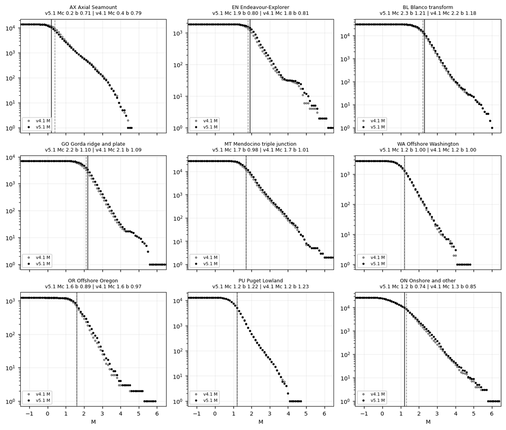

Cumulative FMDs per box, v4.1 and v5.1 magnitudes on the same events; vertical lines at Mc_best.

Notes. The onshore box (ON) mixes Mount St. Helens (Mc near 0) with the rest; its MAXC and MBS values are not meaningful (MAXC 0.7, MBS 2.6), use GFT or the node maps. Axial's pooled GFT Mc was unstable in v4 (bootstrap sigma 0.94); with v5.1 magnitudes it is 0.2 with bootstrap sigma 0.00 (MAXC+0.2 0.5); with the Mc this unstable, the sign of the AX b change depends on the Mc chosen (paired test). Offshore Oregon (OR) has only 1248 events; its paired b change is -0.073 ± 0.017. Mc and b are in the preferred magnitude M (ML for 99.9% of events).

## Open issues

- **Unconstrained station term.** 7D.J35C S (2013-08-09 epoch) appears only in 9 events that have no other pick within 150 km. Its phase19 term is undetermined and takes -234 (v4.1 run: -261), which absorbs the S-phase gauge (sum of S terms = 0). The 9 events are 'mapped' and unaffected; the absolute level is fixed by the ComCat anchors. Same in v4.1. Proposed fix for the next version: drop station-phase terms not linked to any event with a second station, and use one gauge.
- **Weakly tied ocean-bottom terms.** The 2013-14 7D FN stations and J49C have terms of +2 to +6 log10 units that move by up to 2.8 between runs; several of their events have all their 'near' picks on these stations, so their ML moves with them (e.g. event 74485: -1.52 in v5.1, +0.23 in v4.1). 150 events have all their 'near' picks on station-phase terms with fewer than 20 picks; 78 of them have an ML and carry ml_caution weak_terms (the others have no ML). Terms this large point to a response problem on those channels.
- **Short distances.** Hutton-Boore is used down to r of 1 km (Mount St. Helens, Axial). Small depth changes move these ML by 0.3-1; Axial ML fell by 0.11.
- **Mapped events.** 39 'mapped' events have ML ≥ 4 without a tensor; their ML is a lower bound (phase19 docstring).
- **Tensor events are deeper in v5.1.** Median +13.7 km against ComCat (v4: -2.1); 8 events moved beyond the 5 s / 50 km match. For the location work.
- **Offshore ML against outside references.** Our ML sits 0.3-0.5 above ComCat ML at Mendocino, Blanco and Gorda and agrees onshore; the single anchor offset is set mostly by onshore anchors (2,724 of 3,561). v5.1 made the offshore agreement worse with both references: the ComCat ML gap widened by 0.07 to 0.15, and ML - Mw for Mw 3-4.5 tensor events on offshore and coastal labels went from -0.05 to +0.08. Most of both the gap and its growth comes from the unconverged phase19 inversion: converged, the offshore gaps to ComCat ML and to tensor Mw shrink to about 0.0-0.3 (section above). The production M was not changed. Open: converge the solver (PI decision, affects v4.1 too) and recheck on v6.0.
- **Unconverged phase19 inversion.** LSQR stops at 3000 iterations; converged (4,863), offshore regional ML levels move by -0.68 to +0.10. Pre-existing in v4.1. Not fixed here.
- **Poorly constrained depths.** floor_limited, far_only, deep-pass and five-phase events get a magnitude like any other, but their ML depends on the depth. The table has the flags, the catalog's depth_quality (18,168 unconstrained and 6,611 biased_deep among rows with ML) and ml_caution (2,807 rows) so that users can filter. M is not changed for any of them.

## Files

[output not shown]

### References

- Hutton, L. K., & Boore, D. M. (1987). The ML scale in southern California. BSSA 77(6), 2074-2094.
- Aki, K. (1965). Bull. Earthq. Res. Inst. 43, 237-239. Utsu, T. (1965). Geophys. Bull. Hokkaido Univ. 13, 99-103.
- Shi, Y., & Bolt, B. A. (1982). BSSA 72(5), 1677-1687. doi:10.1785/BSSA0720051677
- Wiemer, S., & Wyss, M. (2000). BSSA 90(4), 859-869. doi:10.1785/0119990114
- Cao, A., & Gao, S. S. (2002). GRL 29(9), 1334. doi:10.1029/2001GL013775
- Woessner, J., & Wiemer, S. (2005). BSSA 95(2), 684-698. doi:10.1785/0120040007